# BDA400 Assignment 2 - Technical Analysis using R (Preliminary Stage)

Marwah Mahsal Khan

2026-09-28

## Setup

All the functions live in `stock_functions.R` so this file just loads them and runs them. `quantmod` and `TTR` get loaded inside that script.

```r
source("stock_functions.R")
```

## Portfolio

The stock symbols are stored in `portfolio.txt`, one per line.

```r
symbols <- read_portfolio("portfolio.txt")
symbols
```

```
## [1] "AAPL" "MSFT" "NVDA" "AMZN" "TSLA"
```

## Importing the Data

`load_stock_data()` reads `portfolio.txt` and downloads daily prices for each symbol from Yahoo Finance (Jan 1 - Dec 31, 2025). Each stock ends up as its own data frame inside a named list.

```r
stocks <- load_stock_data("portfolio.txt", from = "2025-01-01", to = "2026-01-01")

names(stocks)
```

```
## [1] "AAPL" "MSFT" "NVDA" "AMZN" "TSLA"
```

```r
sapply(stocks, class)   # each one is a separate data frame
```

```
##         AAPL         MSFT         NVDA         AMZN         TSLA
## "data.frame" "data.frame" "data.frame" "data.frame" "data.frame"
```

```r
sapply(stocks, nrow)    # number of trading days per stock
```

```
## AAPL MSFT NVDA AMZN TSLA
##  250  250  250  250  250
```

Structure of one of the data frames:

```r
str(stocks[[1]])
```

```
## 'data.frame':    250 obs. of  7 variables:
##  $ Date    : Date, format: "2025-01-02" "2025-01-03" ...
##  $ Open    : num  249 243 244 243 242 ...
##  $ High    : num  249 244 247 246 244 ...
##  $ Low     : num  242 242 243 241 240 ...
##  $ Close   : num  244 243 245 242 243 ...
##  $ Volume  : num  55740700 40244100 45045600 40856000 37628900 ...
##  $ Adjusted: num  242 242 243 240 241 ...
```

The data is also saved as CSV files in an `output/` folder.

```r
save_stock_data(stocks)
```

## Displaying the Data

### Historical data (last 10 trading days)

Same layout as the Historical Data tab on Yahoo Finance, newest day first.

```r
for (sym in names(stocks)) {
  cat("\n\n####", sym, "\n\n")
  print(knitr::kable(display_historical(stocks[[sym]], sym, n = 10),
                     align = "r"))
}
```

#### AAPL

AAPL - last 10 trading days

| Date | Open | High | Low | Close | Adj Close | Volume |
| --- | --- | --- | --- | --- | --- | --- |
| Dec 31, 2025 | 273.06 | 273.68 | 271.75 | 271.86 | 271.12 | 27,293,600 |
| Dec 30, 2025 | 272.81 | 274.08 | 272.28 | 273.08 | 272.34 | 22,139,600 |
| Dec 29, 2025 | 272.69 | 274.36 | 272.35 | 273.76 | 273.02 | 23,715,200 |
| Dec 26, 2025 | 274.16 | 275.37 | 272.86 | 273.40 | 272.66 | 21,521,800 |
| Dec 24, 2025 | 272.34 | 275.43 | 272.20 | 273.81 | 273.07 | 17,910,600 |
| Dec 23, 2025 | 270.84 | 272.50 | 269.56 | 272.36 | 271.62 | 29,642,000 |
| Dec 22, 2025 | 272.86 | 273.88 | 270.51 | 270.97 | 270.23 | 36,571,800 |
| Dec 19, 2025 | 272.15 | 274.60 | 269.90 | 273.67 | 272.93 | 144,632,000 |
| Dec 18, 2025 | 273.61 | 273.63 | 266.95 | 272.19 | 271.45 | 51,630,700 |
| Dec 17, 2025 | 275.01 | 276.16 | 271.64 | 271.84 | 271.10 | 50,138,700 |

#### MSFT

MSFT - last 10 trading days

| Date | Open | High | Low | Close | Adj Close | Volume |
| --- | --- | --- | --- | --- | --- | --- |
| Dec 31, 2025 | 487.84 | 488.14 | 483.30 | 483.62 | 480.57 | 15,601,600 |
| Dec 30, 2025 | 485.93 | 489.68 | 485.50 | 487.48 | 484.41 | 13,944,500 |
| Dec 29, 2025 | 484.86 | 488.35 | 484.18 | 487.10 | 484.03 | 10,893,400 |
| Dec 26, 2025 | 486.71 | 488.12 | 485.96 | 487.71 | 484.64 | 8,842,200 |
| Dec 24, 2025 | 485.68 | 489.16 | 484.83 | 488.02 | 484.94 | 5,855,900 |
| Dec 23, 2025 | 484.98 | 487.83 | 484.74 | 486.85 | 483.78 | 14,683,600 |
| Dec 22, 2025 | 486.12 | 488.73 | 482.69 | 484.92 | 481.86 | 16,963,000 |
| Dec 19, 2025 | 487.36 | 487.85 | 482.49 | 485.92 | 482.86 | 70,836,100 |
| Dec 18, 2025 | 478.19 | 489.60 | 477.89 | 483.98 | 480.93 | 28,573,500 |
| Dec 17, 2025 | 476.91 | 480.00 | 475.00 | 476.12 | 473.12 | 24,527,200 |

#### NVDA

NVDA - last 10 trading days

| Date | Open | High | Low | Close | Adj Close | Volume |
| --- | --- | --- | --- | --- | --- | --- |
| Dec 31, 2025 | 189.57 | 190.56 | 186.49 | 186.50 | 186.06 | 120,100,500 |
| Dec 30, 2025 | 188.24 | 188.99 | 186.93 | 187.54 | 187.10 | 97,687,300 |
| Dec 29, 2025 | 187.71 | 188.76 | 185.91 | 188.22 | 187.78 | 120,006,100 |
| Dec 26, 2025 | 189.92 | 192.69 | 188.00 | 190.53 | 190.09 | 139,740,300 |
| Dec 24, 2025 | 187.94 | 188.91 | 186.59 | 188.61 | 188.17 | 65,528,500 |
| Dec 23, 2025 | 182.97 | 189.33 | 182.90 | 189.21 | 188.77 | 174,873,600 |
| Dec 22, 2025 | 183.92 | 184.16 | 182.35 | 183.69 | 183.26 | 129,064,400 |
| Dec 19, 2025 | 176.67 | 181.45 | 176.34 | 180.99 | 180.57 | 324,925,900 |
| Dec 18, 2025 | 174.53 | 176.15 | 171.82 | 174.14 | 173.73 | 176,096,000 |
| Dec 17, 2025 | 176.10 | 176.13 | 170.31 | 170.94 | 170.54 | 222,775,500 |

#### AMZN

AMZN - last 10 trading days

| Date | Open | High | Low | Close | Adj Close | Volume |
| --- | --- | --- | --- | --- | --- | --- |
| Dec 31, 2025 | 232.91 | 232.99 | 230.12 | 230.82 | 230.82 | 24,383,700 |
| Dec 30, 2025 | 231.21 | 232.77 | 230.20 | 232.53 | 232.53 | 21,910,500 |
| Dec 29, 2025 | 231.94 | 232.60 | 230.77 | 232.07 | 232.07 | 19,797,900 |
| Dec 26, 2025 | 232.04 | 232.99 | 231.18 | 232.52 | 232.52 | 15,994,700 |
| Dec 24, 2025 | 232.13 | 232.95 | 231.33 | 232.38 | 232.38 | 11,420,500 |
| Dec 23, 2025 | 229.06 | 232.45 | 228.73 | 232.14 | 232.14 | 29,230,200 |
| Dec 22, 2025 | 228.61 | 229.48 | 226.71 | 228.43 | 228.43 | 32,261,300 |
| Dec 19, 2025 | 226.76 | 229.13 | 225.58 | 227.35 | 227.35 | 85,544,400 |
| Dec 18, 2025 | 225.71 | 229.23 | 224.41 | 226.76 | 226.76 | 50,272,400 |
| Dec 17, 2025 | 224.66 | 225.19 | 220.99 | 221.27 | 221.27 | 44,034,400 |

#### TSLA

TSLA - last 10 trading days

| Date | Open | High | Low | Close | Adj Close | Volume |
| --- | --- | --- | --- | --- | --- | --- |
| Dec 31, 2025 | 456.10 | 456.55 | 449.30 | 449.72 | 449.72 | 49,078,000 |
| Dec 30, 2025 | 461.09 | 463.12 | 453.83 | 454.43 | 454.43 | 59,238,500 |
| Dec 29, 2025 | 469.00 | 469.40 | 459.00 | 459.64 | 459.64 | 66,263,000 |
| Dec 26, 2025 | 485.23 | 489.09 | 473.82 | 475.19 | 475.19 | 58,780,700 |
| Dec 24, 2025 | 488.48 | 490.90 | 476.80 | 485.40 | 485.40 | 41,285,400 |
| Dec 23, 2025 | 489.40 | 491.97 | 482.84 | 485.56 | 485.56 | 58,223,600 |
| Dec 22, 2025 | 489.88 | 498.83 | 485.33 | 488.73 | 488.73 | 86,916,100 |
| Dec 19, 2025 | 488.12 | 490.49 | 474.72 | 481.20 | 481.20 | 103,305,400 |
| Dec 18, 2025 | 478.16 | 490.86 | 473.12 | 483.37 | 483.37 | 95,168,400 |
| Dec 17, 2025 | 488.22 | 495.28 | 466.20 | 467.26 | 467.26 | 106,490,400 |

### Quote summary

A summary box like the one at the top of a Yahoo Finance stock page. “Period Range” is the lowest low and highest high over the whole year.

```r
for (sym in names(stocks)) {
  cat("\n\n####", sym, "\n\n")
  print(knitr::kable(display_quote_summary(stocks[[sym]], sym)))
}
```

#### AAPL

| Item | Value |
| --- | --- |
| Last Close | 271.86 |
| Previous Close | 273.08 |
| Open | 273.06 |
| Day’s Range | 271.75 - 273.68 |
| Period Range | 169.21 - 288.62 |
| Volume | 27,293,600 |
| Avg. Volume | 54,175,778 |

#### MSFT

| Item | Value |
| --- | --- |
| Last Close | 483.62 |
| Previous Close | 487.48 |
| Open | 487.84 |
| Day’s Range | 483.30 - 488.14 |
| Period Range | 344.79 - 555.45 |
| Volume | 15,601,600 |
| Avg. Volume | 22,193,442 |

#### NVDA

| Item | Value |
| --- | --- |
| Last Close | 186.50 |
| Previous Close | 187.54 |
| Open | 189.57 |
| Day’s Range | 186.49 - 190.56 |
| Period Range | 86.62 - 212.19 |
| Volume | 120,100,500 |
| Avg. Volume | 220,750,955 |

#### AMZN

| Item | Value |
| --- | --- |
| Last Close | 230.82 |
| Previous Close | 232.53 |
| Open | 232.91 |
| Day’s Range | 230.12 - 232.99 |
| Period Range | 161.38 - 258.60 |
| Volume | 24,383,700 |
| Avg. Volume | 44,439,366 |

#### TSLA

| Item | Value |
| --- | --- |
| Last Close | 449.72 |
| Previous Close | 454.43 |
| Open | 456.10 |
| Day’s Range | 449.30 - 456.55 |
| Period Range | 214.25 - 498.83 |
| Volume | 49,078,000 |
| Avg. Volume | 97,696,560 |

## Statistics

`calculate_statistics()` works on the daily closing price for each stock: mean, median, mode, standard deviation, min, max, and the latest 20-day and 50-day simple moving averages. `calculate_all_statistics()` runs it on every stock and puts the results into one table.

```r
stats <- calculate_all_statistics(stocks)
knitr::kable(stats)
```

| Symbol | From | To | Days | Mean | Median | Mode | SD | Min | Max | SMA_20_Last | SMA_50_Last |
| --- | --- | --- | --- | --- | --- | --- | --- | --- | --- | --- | --- |
| AAPL | 2025-01-02 | 2025-12-31 | 250 | 232.24 | 230.00 | 211 | 26.47 | 172.42 | 286.19 | 275.47 | 272.66 |
| MSFT | 2025-01-02 | 2025-12-31 | 250 | 464.43 | 479.69 | 510 | 50.52 | 354.56 | 542.07 | 483.41 | 496.51 |
| NVDA | 2025-01-02 | 2025-12-31 | 250 | 153.90 | 158.79 | 178 | 29.77 | 94.31 | 207.04 | 182.50 | 186.36 |
| AMZN | 2025-01-02 | 2025-12-31 | 250 | 217.67 | 222.12 | 223 | 17.10 | 167.32 | 254.00 | 228.77 | 231.44 |
| TSLA | 2025-01-02 | 2025-12-31 | 250 | 356.97 | 344.04 | 285 | 69.98 | 221.86 | 489.88 | 464.70 | 445.10 |

A few notes on how these are calculated:

- **Mode** - base R doesn’t have a mode function, and closing prices basically never repeat to the exact cent, so prices are rounded to the nearest dollar first and the most common value is taken.
- **SD** - `sd()` gives the sample standard deviation (divides by n - 1).
- **Moving averages** - `SMA()` from the TTR package. The value shown is from the last trading day of the year.

## Visualizations

### Closing price with moving averages

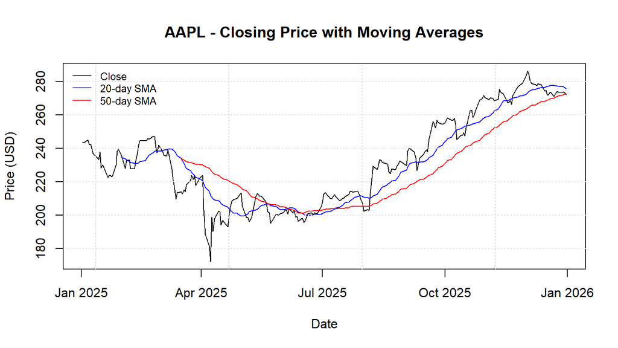

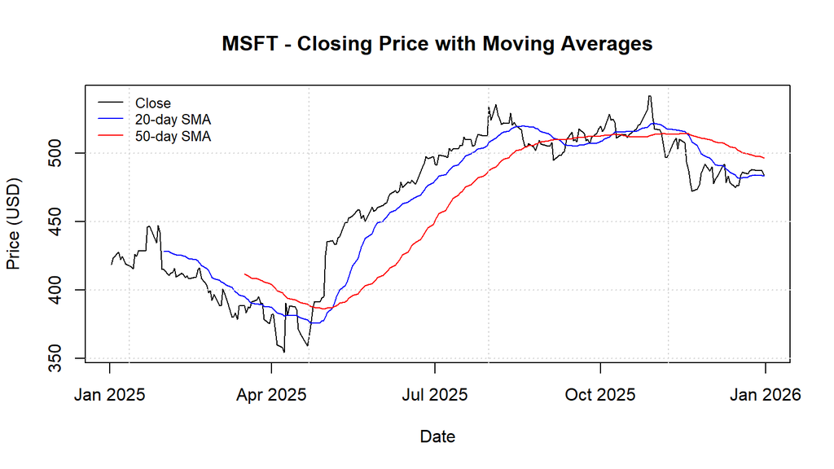

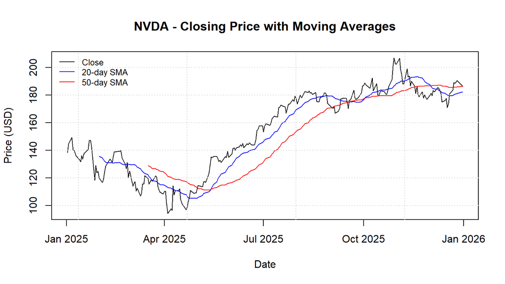

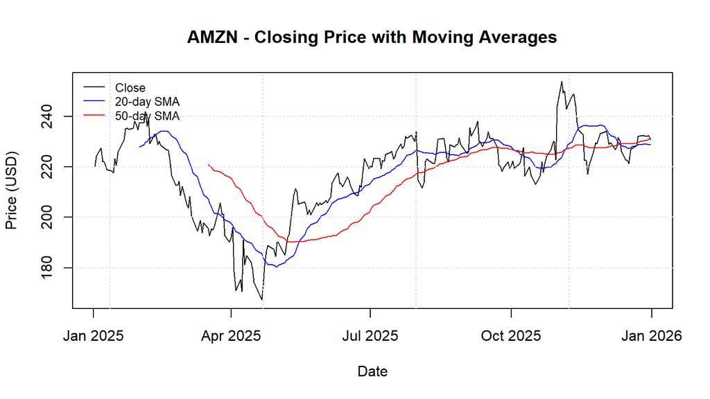

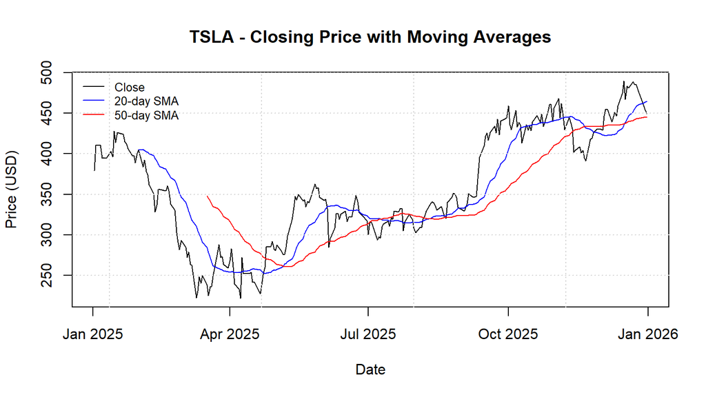

```r
for (sym in names(stocks)) {
  plot_price_with_ma(stocks[[sym]], sym)
}
```

### Candlestick charts with volume (quantmod)

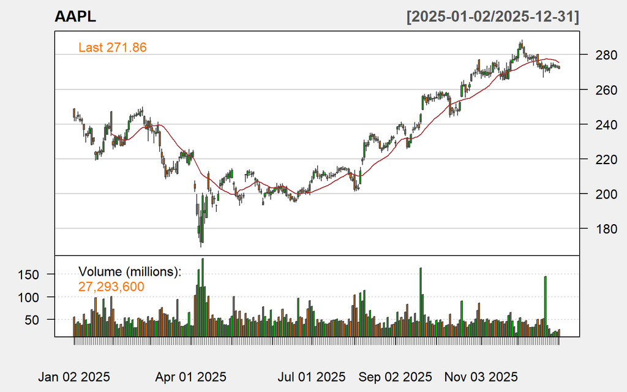

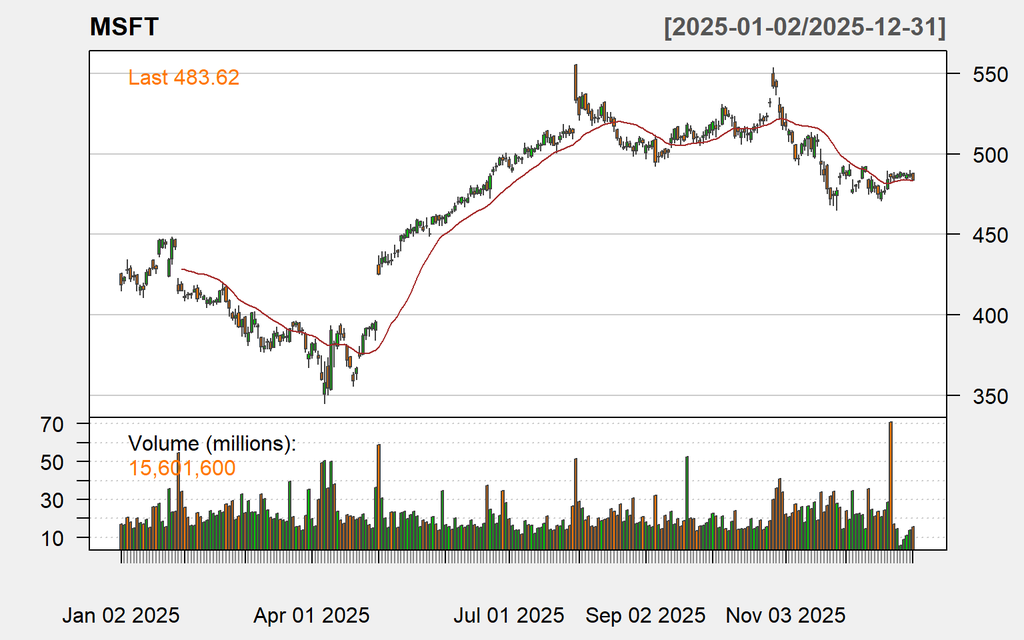

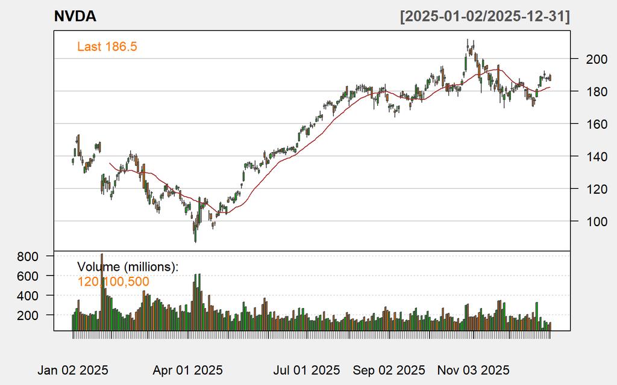

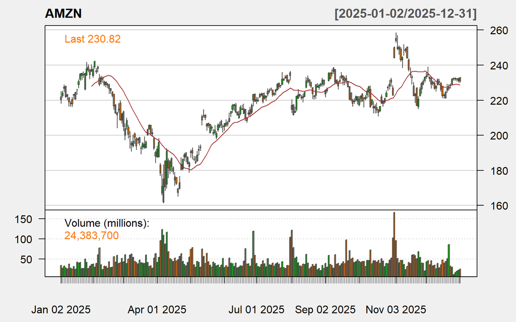

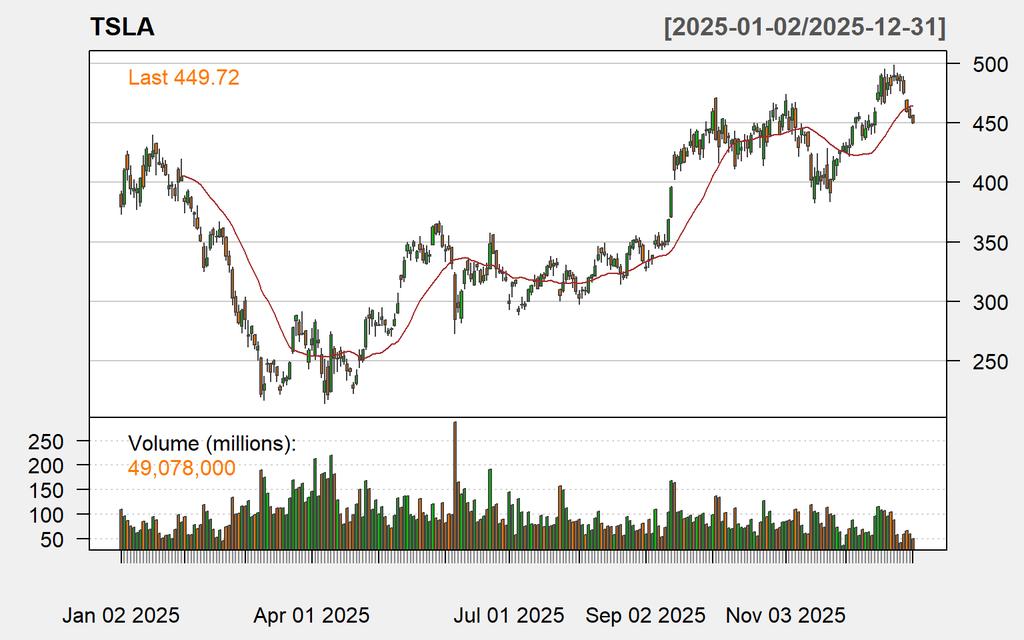

```r
for (sym in names(stocks)) {
  plot_candlestick(stocks[[sym]], sym)
}
```

### Relative performance of the whole portfolio

Every stock starts at 100 on the first trading day so they can be compared on one chart.

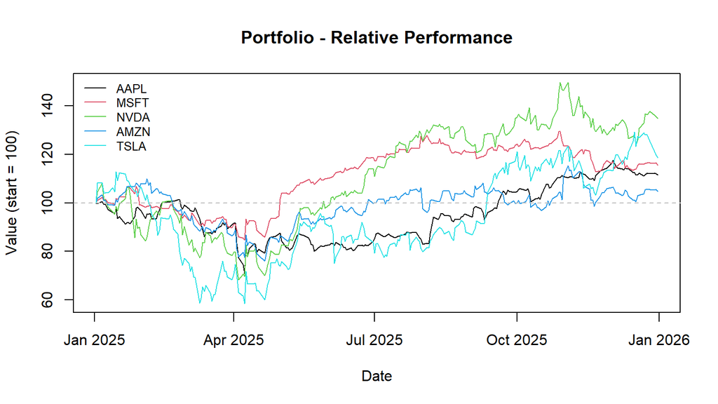

```r
plot_normalized(stocks)
```